# Week 2

Programming in Psychological Science

### Assignment description

Welcome back!

Like last week, you will work on coding tasks coming from (R + Python) OR (R + advanced R). If you only submit a .R file on canvas, we assume you want to be graded on R + advanced R. If there is a .R file AND a python file, then you will be graded on R + Python.

This week’s assignment is worth 5 points (4 for R + 1 extra; 5% of your final course grade). You must work individually, but feel free to ask questions in class and on Slack!

It is extremely important to put comments in your script to show which of your code pieces belong to which task. Keep the code in order with the numbered tasks with comments like.

It is very normal to experience plenty of confusion have lots of questions while coding. If you are stuck, even after googling and trying various things, please ALWAYS contact us via Slack (or in class), no matter if you already did so many times. One thing that will get you quicker answers is providing the TA with code that they can copy paste into their R Studio to see the error you are struggling with. Only include code in private messages though. No code on public Slack channels, please.

This week’s assignment has various exercises that can be tackled in different ways. So if you want to use a different approach or package than your classmates, that is fine! We also do not mind what colors you pick for your plots or if font sizes and other design details differ.

### R questions

#R1

Make a scatterplot of the mean temperatures measured at Schiphol Airport. Put the time (year) on the x-axis and temperature (TAVG) on the y axis. The data can be loaded from here: https://raw.githubusercontent.com/hannesrosenbusch/PIPS_DATA/master/schiphol.csv

#R2

The day that the titanic sank was bad, mostly because it bolsters present-day misogyny with plots like this:

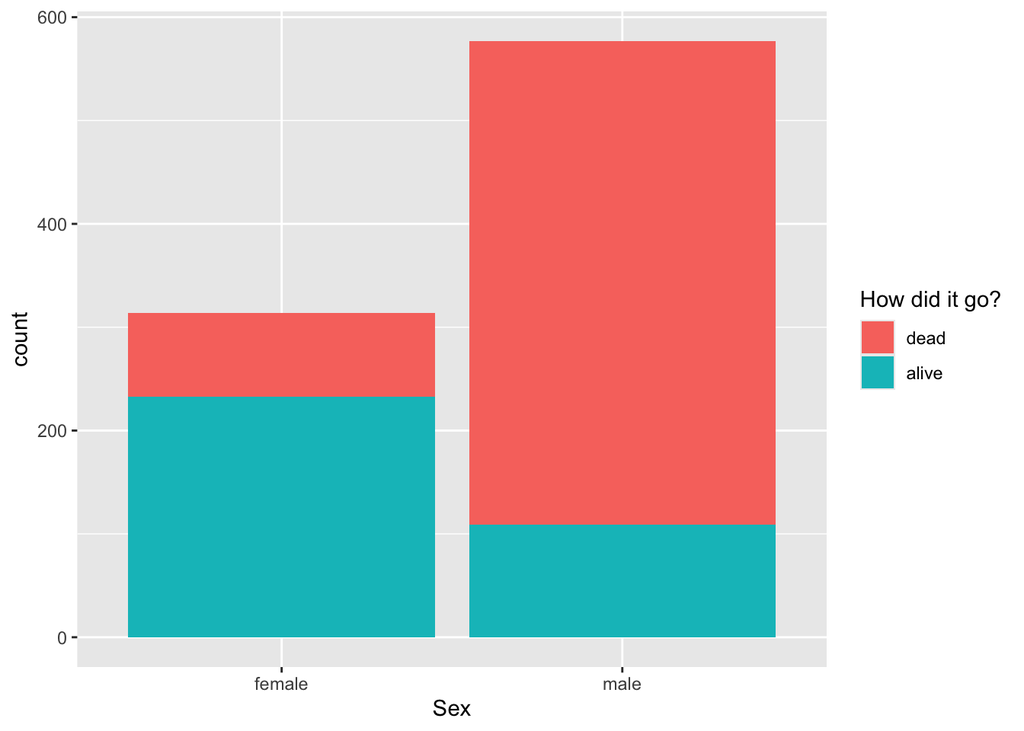

Can you recreate the barplot with the ggplot2 and titanic packages (dataset titanic_train has the passenger data)? Functions that might be useful are factor() and labs(fill = “my label”).

#R3

Try out different themes from ggplot for the previous plot. You can find ggplot’s “complete themes” here: https://ggplot2.tidyverse.org/reference/ggtheme.html . Name one theme that you like and explain why you like it in ONE sentence. There are no right or wrong choices.

#R4

Change three things about this plot that make it easier to understand and list each improvement in an extremely short bullet point comment.

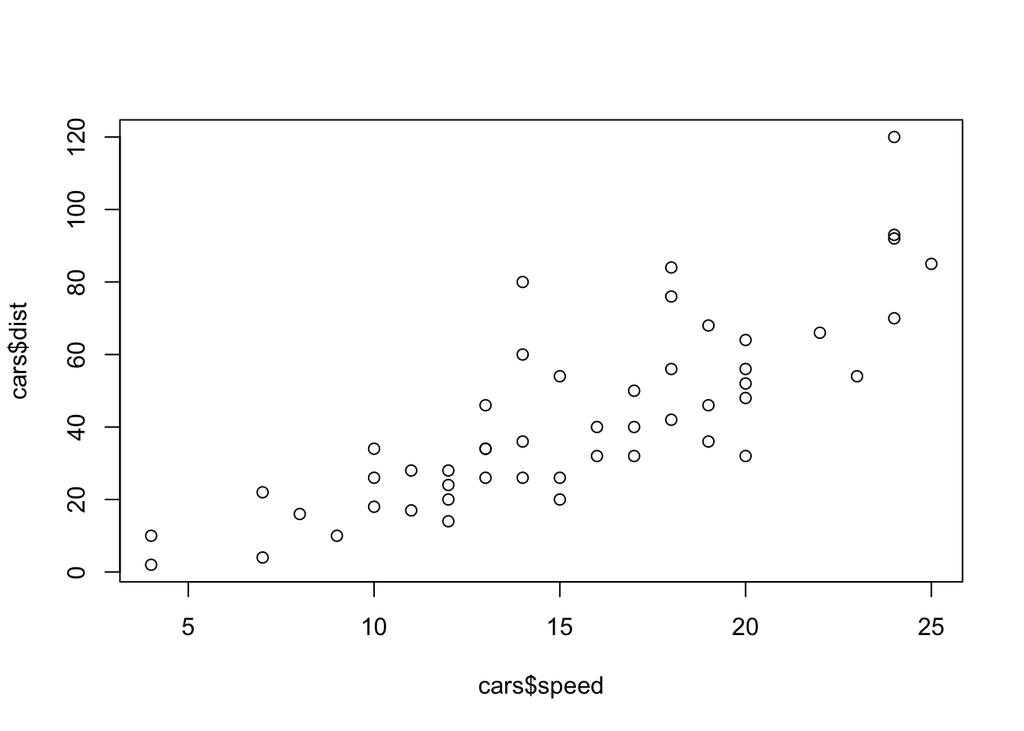

```r
plot(cars$speed, cars$dist)
```

#R5

Use the built-in ChickWeight dataset and recreate this ggplot. Make sure the bars are shown in the same order as here. Notice that you have to compute the chickens’ maximum weight before plotting. Useful things to look up: aggregate() as well as %in%

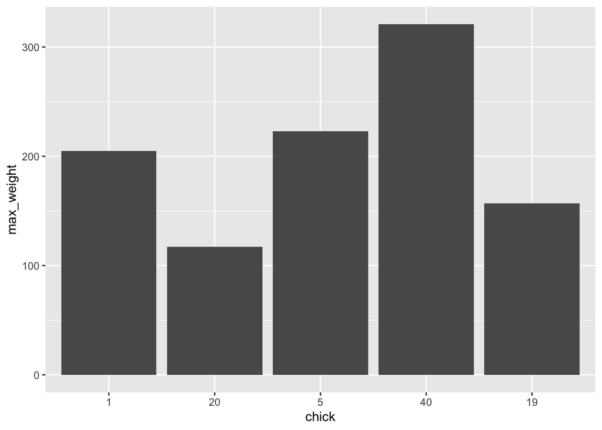

#R6

Recreate this ggplot with the cars dataset.

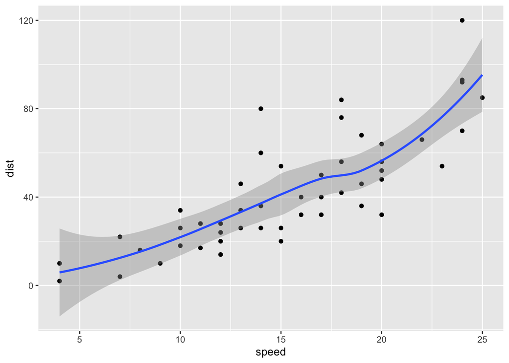

#R7

Ever wondered if guinea pigs’ teeth grow better when they take their vitamin C through orange juice rather than meds? Make a plot that answers this question with the ggstatsplot package using the ToothGrowth datset. Hint: when checking out the ggstatsplot package: this is a “between subject” comparison ;)

#R8

Recreate this movable 3D plot with the plotly package and the human body measurements (in inches) dataset. You can load it from https://raw.githubusercontent.com/hannesrosenbusch/PIPS_DATA/master/body.csv.

If plotly’s html plots don’t show up in your RStudio (while also giving no error), try this: `htmlwidgets::saveWidget(myplot, "myplot.html")`

`browseURL("myplot.html")`

[interactive chart not shown]

#R9

Create a gif file with this plot using the gganimate package. Maybe look up transition_reveal() in the process. You can get the data through the cran_downloads() function from the package cranlogs. The animation speed and other visual settings do not matter for grading. Set the values low to not challenge your computer too much. You might also need to download the gifski package for everything to look nice. Some programs (like preview) don’t show gifs, so you might want to save the gif and open it with your browser.

[figure not shown]

#R11

State in one sentence what the purpose of the code below is (running it and adding printouts helps) and list exactly five reasons why the code has very poor style (there are more). Do one reason per comment. Two or three words per reason should usually be enough.

```r
a <- "dog"
b = "cat"
v = function(x){
xx <- strsplit(x, "", )[[1]]
yy <- strsplit(b, "", )[[1]]
lxx = length(xx)
lyy = length(yy)
v <- lxx == lyy
if(v) return(T)
}
v(a)
```

```
## [1] TRUE
```

#R12

Construct this matrix with one line of code and a single function (one pair of parentheses):

```
##      [,1] [,2] [,3]
## [1,]    1    2    3
## [2,]    8   10   12
## [3,]   21   24   27
```

#R13

Find the keyboard shortcut that automatically formats your highlighted R code nicely. Mention it in a comment, and use it from now on :)

#R14

Make a meme in RStudio about R coding. You can (but do not have to) use the memer package (installation requires install_github() function from the devtools package). Indicate in a comment whether you are fine with us posting the meme anonymously to the meme channel on Slack. The person contributing the meme getting most likes will be reposted in the following years that this course is given! These are the winners from the last years.

2024:

[figure not shown]

2025:

[figure not shown]

2026 (January):

[figure not shown]

### R advanced questions

#Radv1

Make some random art. Your code should produce a different piece of art when one changes the random seed atop your code. Only use built-in functions and/or ggplot.

### Python questions

#Python1

Load the tips dataset from the seaborn package. Make a scatter plot with `total_bill` on the x axis and `tip` on the y axis. Add a regression line to the plot. Label your x-axis and y-axis with the variable names in large font size.

#Python2

Let’s analyze the quality of diamonds. Plot a heatmap showing all the correlations between the numeric variables in the diamonds dataset from seaborn. Next to the heatmap, add a `kdeplot` with carat on the x axis and price on the y axis.

#Python3

Look through your solutions from any previous Python exercises (this week or in previous weeks) where you wrote your own Python code. Improve style of of your code by following PEP8 (Python Enhancement Proposal 8). Write two comments, each one specifying one edit that improved coding style.